# Auswertung Kongruenzstudie

Elenea Wieland und Oliver Schallert

17.05.23

## Pakete und Daten

```r
library(dplyr)
library(tidyr)
library(car)
library(lme4)
library(ggplot2)
library(Hmisc)
library(cAIC4)
```

## Daten einlesen und bereinigen

```r
daten <- read.csv("/Users/uetzelsche/Desktop/2023-04-Datensatz.csv", sep=";", row.names=,1, na.strings="")

daten_kongruenz <- daten %>%
  select(CASE, matches("[FIS][ABCDEFHGIJKL]")) %>%
  select(!c(2, 111:115)) %>%
  select(!2:13)

# Daten ins Long-Format konvertieren

daten_kongruenz_mod <- pivot_longer(daten_kongruenz, starts_with("S"), names_to = "Bedingung", values_to = "Bewertung")
```

NAs aussortieren, Items aus den einzelnen Bedingungen herauslösen, Bedingungen separieren und rekodieren.

```r
daten_kongruenz_mod <- drop_na(daten_kongruenz_mod)

daten_kongruenz_mod$Item <- substr(daten_kongruenz_mod$Bedingung, 2, 2)

daten_kongruenz_mod$Bedingung <- substr(daten_kongruenz_mod$Bedingung, 4, 4)

bedingung_nr <- as.numeric(daten_kongruenz_mod$Bedingung)

bedingungen <- c("SV.Sg.adj", "SV.Pl.adj", "VS.Sg.adj", "VS.Pl.adj", "SV.Sg.dist", "SV.Pl.dist", "VS.Sg.dist", "VS.Pl.dist")

daten_kongruenz_mod$Bedingung <- bedingungen[bedingung_nr]
```

Bedingung in drei Spalten aufteilen und Spaltenreihenfolge ändern; jeweils als Faktoren rekodieren.

```r
daten_kongruenz_mod <- separate(daten_kongruenz_mod, "Bedingung", into=c("Wortstellung", "Kongruenz", "Distanz"))

col_abfolge <- c("CASE", "Item", "Wortstellung", "Kongruenz", "Distanz", "Bewertung")

daten_kongruenz_mod <- daten_kongruenz_mod[, col_abfolge]

daten_kongruenz_mod$Wortstellung <- factor(daten_kongruenz_mod$Wortstellung)

daten_kongruenz_mod$Kongruenz <- factor(daten_kongruenz_mod$Kongruenz)

daten_kongruenz_mod$Distanz <- factor(daten_kongruenz_mod$Distanz)

daten_kongruenz_mod$Item <- factor(daten_kongruenz_mod$Item)
```

Teilstudien aus dem Datensatz herauslösen.

```r
zweifelsfall1 <- filter(daten_kongruenz_mod, Item %in% c("A", "B", "C", "D"))

zweifelsfall2 <- filter(daten_kongruenz_mod, Item %in% c("E", "F", "G", "H"))

zweifelsfall3 <- filter(daten_kongruenz_mod, Item %in% c("I", "J", "K", "L"))
```

## Deskriptive Auswertung

Tabellen mit Mittelwerten der Bewertungen nach Bedingungen erzeugen. Man kann das noch schöner machen (mit Standardabweichung usw.).

```r
tab_zweifelsfall1 <- xtabs(Bewertung ~ Wortstellung + Kongruenz + Distanz, aggregate(Bewertung ~ Wortstellung + Kongruenz + Distanz, zweifelsfall1, mean))

tab_zweifelsfall2 <- xtabs(Bewertung ~ Wortstellung + Kongruenz + Distanz, aggregate(Bewertung ~ Wortstellung + Kongruenz + Distanz, zweifelsfall2, mean))

tab_zweifelsfall3 <- xtabs(Bewertung ~ Wortstellung + Kongruenz + Distanz, aggregate(Bewertung ~ Wortstellung + Kongruenz + Distanz, zweifelsfall3, mean))

tab_zweifelsfall1
```

```
## , , Distanz = adj
##
##             Kongruenz
## Wortstellung       Pl       Sg
##           SV 1.928571 3.187500
##           VS 1.830357 3.348214
##
## , , Distanz = dist
##
##             Kongruenz
## Wortstellung       Pl       Sg
##           SV 2.089286 3.428571
##           VS 1.892857 2.767857
```

```r
tab_zweifelsfall2
```

```
## , , Distanz = adj
##
##             Kongruenz
## Wortstellung       Pl       Sg
##           SV 3.043860 1.938596
##           VS 3.464912 1.649123
##
## , , Distanz = dist
##
##             Kongruenz
## Wortstellung       Pl       Sg
##           SV 3.403509 1.991228
##           VS 3.289474 1.833333
```

```r
tab_zweifelsfall3
```

```
## , , Distanz = adj
##
##             Kongruenz
## Wortstellung       Pl       Sg
##           SV 2.563636 3.109091
##           VS 2.227273 3.054545
##
## , , Distanz = dist
##
##             Kongruenz
## Wortstellung       Pl       Sg
##           SV 2.609091 3.318182
##           VS 2.309091 2.590909
```

## Statistische Auswertung

Statistische Analyse mittels gemischtem linearen Modell. Wir führen zuerst eine Kontrastkodierung der Daten durch. In einem nächsten Schritt passen wir Modelle für die drei Teilstudien an. Wir verwenden jeweils maximale Modelle mit `Bewertung ~ Wortstellung + Kongruenz + Distanz` als fixen Effekten und `Item` und Versuchsperson (`CASE`) als zufälligen Effekten.

```r
contrasts(daten_kongruenz_mod$Wortstellung) <- contr.Sum(levels(daten_kongruenz_mod$Wortstellung))

contrasts(daten_kongruenz_mod$Kongruenz) <- contr.Sum(levels(daten_kongruenz_mod$Kongruenz))

contrasts(daten_kongruenz_mod$Distanz) <- contr.Sum(levels(daten_kongruenz_mod$Distanz))
```

### Teilstudie 1 (Zweifelsfall 1)

Wir passen zuerst ein Maximalmodell an (`modell_zweifelsfall1`). Eine Prüfung der Modellgüte in Bezug auf die zufälligen Faktoren (Rückwärtsselektion modulo AIC) deutet darauf hin, dass einfachere Modelle nicht besser abschneiden. Siehe dazu die Dokumentation zum Paket [cAIC4](https://www.rdocumentation.org/packages/cAIC4/versions/1.0/topics/stepcAIC).

```r
modell_zweifelsfall1 <- lmer(Bewertung ~ Wortstellung + Kongruenz + Distanz + (1|Item) + (1|CASE), zweifelsfall1, REML= TRUE)

summary(modell_zweifelsfall1)
```

```
## Linear mixed model fit by REML ['lmerMod']
## Formula: Bewertung ~ Wortstellung + Kongruenz + Distanz + (1 | Item) +
##     (1 | CASE)
##    Data: zweifelsfall1
##
## REML criterion at convergence: 2576.2
##
## Scaled residuals:
##     Min      1Q  Median      3Q     Max
## -2.3163 -0.7802 -0.0552  0.7610  2.4387
##
## Random effects:
##  Groups   Name        Variance Std.Dev.
##  CASE     (Intercept) 0.06658  0.2580
##  Item     (Intercept) 0.06773  0.2602
##  Residual             0.96972  0.9847
## Number of obs: 896, groups:  CASE, 56; Item, 4
##
## Fixed effects:
##                Estimate Std. Error t value
## (Intercept)     2.04570    0.14984  13.653
## WortstellungVS -0.19866    0.06580  -3.019
## KongruenzSg     1.25459    0.06584  19.056
## Distanzdist    -0.02902    0.06580  -0.441
##
## Correlation of Fixed Effects:
##             (Intr) WrtsVS KngrnS
## WrtstllngVS -0.220
## KongruenzSg -0.220  0.000
## Distanzdist -0.220  0.000  0.000
```

```r
Anova(modell_zweifelsfall1)
```

```
## Analysis of Deviance Table (Type II Wald chisquare tests)
##
## Response: Bewertung
##                 Chisq Df Pr(>Chisq)
## Wortstellung   9.1164  1   0.002533 **
## Kongruenz    363.1492  1  < 2.2e-16 ***
## Distanz        0.1945  1   0.659193
## ---
## Signif. codes:  0 '***' 0.001 '**' 0.01 '*' 0.05 '.' 0.1 ' ' 1
```

```r
zweifelsfall1$FittedBewertung <- fitted(modell_zweifelsfall1)

modell_zweifelsfall1_step <- stepcAIC(modell_zweifelsfall1, direction = "backward", trace = TRUE, data = zweifelsfall1)
```

```
## Starting stepwise procedure...
## _____________________________________________
## _____________________________________________
##
## Step 1 (backward):  cAIC=2555.01
## Best model so far:
## ~ Wortstellung + Kongruenz + Distanz + (1 | CASE) + (1 | Item)
## New Candidates:
##
## Calculating cAIC for 2 model(s) ...
##
##                                            models caic
##  ~Wortstellung + Kongruenz + Distanz + (1 | CASE) 2599
##  ~Wortstellung + Kongruenz + Distanz + (1 | Item) 2583
##
## _____________________________________________
## _____________________________________________
##
## Best model:
##  ~ Wortstellung + Kongruenz + Distanz + (1 | CASE) + (1 | Item) ,
##  cAIC: 2555.01
## _____________________________________________
```

### Teilstudie 2 (Zweifelsfall 2)

Wir passen wiederum zuerst ein Maximalmodell an (`modell_zweifelsfall1`). Eine Prüfung der Modellgüte (Rückwärtsselektion modulo AIC) deutet darauf hin, dass wir Item als zufälligen Faktor verwerfen können. Aus inhaltlichen Überlegungen sollte diese Entscheidung aber kritisch hinterfragt werden. Insbesondere wäre zu schauen, ob es Interaktionen zwischen den zufälligen Faktoren gibt. Das kann man z.B. mit folgenden Term im `lmer`-Objekt spezifizieren: `(1|CASE:Item)`.

```r
modell_zweifelsfall2 <- lmer(Bewertung ~ Wortstellung + Kongruenz + Distanz + (1|Item) + (1|CASE), zweifelsfall2, REML= TRUE)

summary(modell_zweifelsfall2)
```

```
## Linear mixed model fit by REML ['lmerMod']
## Formula: Bewertung ~ Wortstellung + Kongruenz + Distanz + (1 | Item) +
##     (1 | CASE)
##    Data: zweifelsfall2
##
## REML criterion at convergence: 2509.7
##
## Scaled residuals:
##      Min       1Q   Median       3Q      Max
## -3.01205 -0.78199  0.03109  0.72257  2.63175
##
## Random effects:
##  Groups   Name        Variance Std.Dev.
##  CASE     (Intercept) 0.096168 0.31011
##  Item     (Intercept) 0.003628 0.06023
##  Residual             0.847513 0.92060
## Number of obs: 912, groups:  CASE, 57; Item, 4
##
## Fixed effects:
##                Estimate Std. Error t value
## (Intercept)     3.26631    0.07945  41.114
## WortstellungVS -0.03509    0.06097  -0.576
## KongruenzSg    -1.44929    0.06098 -23.767
## Distanzdist     0.10526    0.06097   1.727
##
## Correlation of Fixed Effects:
##             (Intr) WrtsVS KngrnS
## WrtstllngVS -0.384
## KongruenzSg -0.384  0.000
## Distanzdist -0.384  0.000  0.000
```

```r
Anova(modell_zweifelsfall2)
```

```
## Analysis of Deviance Table (Type II Wald chisquare tests)
##
## Response: Bewertung
##                 Chisq Df Pr(>Chisq)
## Wortstellung   0.3312  1    0.56495
## Kongruenz    564.8723  1    < 2e-16 ***
## Distanz        2.9809  1    0.08425 .
## ---
## Signif. codes:  0 '***' 0.001 '**' 0.01 '*' 0.05 '.' 0.1 ' ' 1
```

```r
modell_zweifelsfall2_step <- stepcAIC(modell_zweifelsfall2, direction = "backward", trace = TRUE, data = zweifelsfall2)
```

```
## Starting stepwise procedure...
## _____________________________________________
## _____________________________________________
##
## Step 1 (backward):  cAIC=2484.342
## Best model so far:
## ~ Wortstellung + Kongruenz + Distanz + (1 | CASE) + (1 | Item)
## New Candidates:
##
## Calculating cAIC for 2 model(s) ...
##
##                                            models caic
##  ~Wortstellung + Kongruenz + Distanz + (1 | Item) 2544
##  ~Wortstellung + Kongruenz + Distanz + (1 | CASE) 2484
##
## _____________________________________________
## _____________________________________________
##
## Step 2 (backward):  cAIC=2483.896
## Best model so far:
## ~ Wortstellung + Kongruenz + Distanz + (1 | CASE)
## New Candidates:
##
## Calculating cAIC for 1 model(s) ...
##
##                               models caic
##  ~Wortstellung + Kongruenz + Distanz 2543
##
## _____________________________________________
## _____________________________________________
##
## Best model:
##  ~ Wortstellung + Kongruenz + Distanz + (1 | CASE) ,
##  cAIC: 2483.896
## _____________________________________________
```

```r
modell_zweifelsfall2_mod <- lmer(Bewertung ~ Wortstellung + Kongruenz + Distanz + (1|CASE), zweifelsfall2, REML= TRUE)

zweifelsfall2$FittedBewertung <- fitted(modell_zweifelsfall2_mod)

summary(modell_zweifelsfall2_mod)
```

```
## Linear mixed model fit by REML ['lmerMod']
## Formula: Bewertung ~ Wortstellung + Kongruenz + Distanz + (1 | CASE)
##    Data: zweifelsfall2
##
## REML criterion at convergence: 2510.6
##
## Scaled residuals:
##      Min       1Q   Median       3Q      Max
## -2.96999 -0.78982  0.03842  0.73049  2.63781
##
## Random effects:
##  Groups   Name        Variance Std.Dev.
##  CASE     (Intercept) 0.09599  0.3098
##  Residual             0.85042  0.9222
## Number of obs: 912, groups:  CASE, 57
##
## Fixed effects:
##                Estimate Std. Error t value
## (Intercept)     3.26535    0.07358  44.379
## WortstellungVS -0.03509    0.06107  -0.575
## KongruenzSg    -1.44737    0.06107 -23.699
## Distanzdist     0.10526    0.06107   1.724
##
## Correlation of Fixed Effects:
##             (Intr) WrtsVS KngrnS
## WrtstllngVS -0.415
## KongruenzSg -0.415  0.000
## Distanzdist -0.415  0.000  0.000
```

```r
Anova(modell_zweifelsfall2_mod)
```

```
## Analysis of Deviance Table (Type II Wald chisquare tests)
##
## Response: Bewertung
##                 Chisq Df Pr(>Chisq)
## Wortstellung   0.3301  1    0.56562
## Kongruenz    561.6392  1    < 2e-16 ***
## Distanz        2.9707  1    0.08479 .
## ---
## Signif. codes:  0 '***' 0.001 '**' 0.01 '*' 0.05 '.' 0.1 ' ' 1
```

### Teilstudie 3 (Zweifelsfall 3)

Wir passen zuerst ein Maximalmodell an (`modell_zweifelsfall1`). Eine Prüfung der Modellgüte in Bezug auf die zufälligen Faktoren (Rückwärtsselektion modulo AIC) deutet darauf hin, dass einfachere Modelle nicht besser abschneiden.

```r
zweifelsfall2$FittedBewertung <- fitted(modell_zweifelsfall2)

modell_zweifelsfall3 <- lmer(Bewertung ~ Wortstellung + Kongruenz + Distanz + (1|Item) + (1|CASE), zweifelsfall3, REML= TRUE)

summary(modell_zweifelsfall3)
```

```
## Linear mixed model fit by REML ['lmerMod']
## Formula: Bewertung ~ Wortstellung + Kongruenz + Distanz + (1 | Item) +
##     (1 | CASE)
##    Data: zweifelsfall3
##
## REML criterion at convergence: 2501.9
##
## Scaled residuals:
##      Min       1Q   Median       3Q      Max
## -2.50032 -0.73720  0.08685  0.79303  2.04919
##
## Random effects:
##  Groups   Name        Variance Std.Dev.
##  CASE     (Intercept) 0.16877  0.4108
##  Item     (Intercept) 0.01897  0.1377
##  Residual             0.90562  0.9516
## Number of obs: 880, groups:  CASE, 55; Item, 4
##
## Fixed effects:
##                Estimate Std. Error t value
## (Intercept)     2.61808    0.10922  23.971
## WortstellungVS -0.35455    0.06416  -5.526
## KongruenzSg     0.59566    0.06421   9.276
## Distanzdist    -0.03182    0.06416  -0.496
##
## Correlation of Fixed Effects:
##             (Intr) WrtsVS KngrnS
## WrtstllngVS -0.294
## KongruenzSg -0.294  0.000
## Distanzdist -0.294  0.000  0.000
```

```r
Anova(modell_zweifelsfall3)
```

```
## Analysis of Deviance Table (Type II Wald chisquare tests)
##
## Response: Bewertung
##                Chisq Df Pr(>Chisq)
## Wortstellung 30.5367  1  3.276e-08 ***
## Kongruenz    86.0459  1  < 2.2e-16 ***
## Distanz       0.2459  1     0.6199
## ---
## Signif. codes:  0 '***' 0.001 '**' 0.01 '*' 0.05 '.' 0.1 ' ' 1
```

```r
zweifelsfall3$FittedBewertung <- fitted(modell_zweifelsfall3)

modell_zweifelsfall3_step <- stepcAIC(modell_zweifelsfall3, direction = "backward", trace = TRUE, data = zweifelsfall3)
```

```
## Starting stepwise procedure...
## _____________________________________________
## _____________________________________________
##
## Step 1 (backward):  cAIC=2460.744
## Best model so far:
## ~ Wortstellung + Kongruenz + Distanz + (1 | CASE) + (1 | Item)
## New Candidates:
##
## Calculating cAIC for 2 model(s) ...
##
##                                            models caic
##  ~Wortstellung + Kongruenz + Distanz + (1 | Item) 2568
##  ~Wortstellung + Kongruenz + Distanz + (1 | CASE) 2472
##
## _____________________________________________
## _____________________________________________
##
## Best model:
##  ~ Wortstellung + Kongruenz + Distanz + (1 | CASE) + (1 | Item) ,
##  cAIC: 2460.744
## _____________________________________________
```

## Daten plotten

Plots zu den drei Teilstudien, und zwar zuerst zur Modellgüte (gefittete vs. beobachtete Daten), dann zu allen Effekten.

### Teilstudie 1 (Zweifelsfall 1)

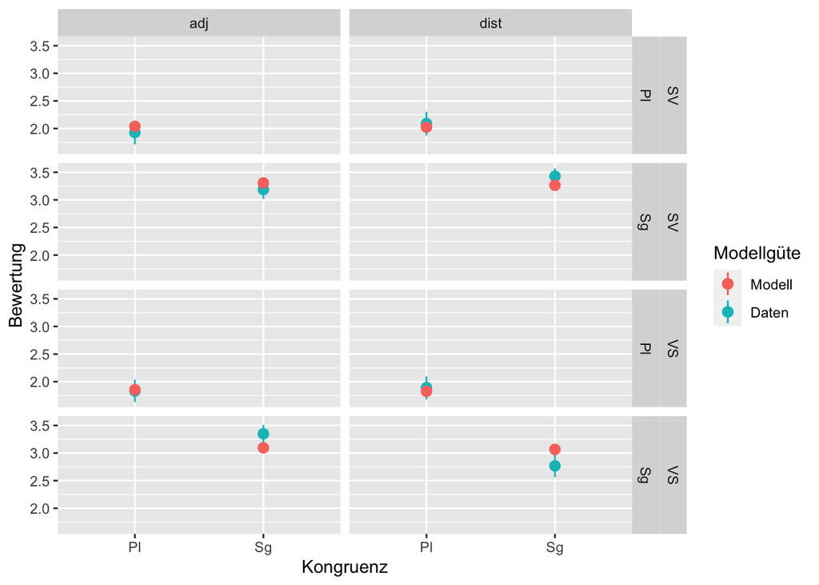

```r
modell_fit_zweifelsfall1 <-
  ggplot(zweifelsfall1, aes(x=Kongruenz, y=Bewertung)) +
  stat_summary(aes(color="observed"), fun.data=mean_cl_boot) +
  stat_summary(aes(y=FittedBewertung, color="model"), fun.data=mean_cl_boot) + facet_grid(Wortstellung ~ Kongruenz ~ Distanz) + xlab("Kongruenz") + ylab("Bewertung") + scale_color_discrete(name  ="Modellgüte", breaks=c("model", "observed"), labels=c("Modell", "Daten"))

alle_effekte_zweifelsfall1 <-
  ggplot(zweifelsfall1, aes(x=Kongruenz, y=Bewertung, color=Wortstellung)) + stat_summary(fun.data=mean_cl_boot) + facet_wrap(~Distanz) + xlab("Kongruenz") + ylab("Bewertung") + ylim(0, 4)

modell_fit_zweifelsfall1
```

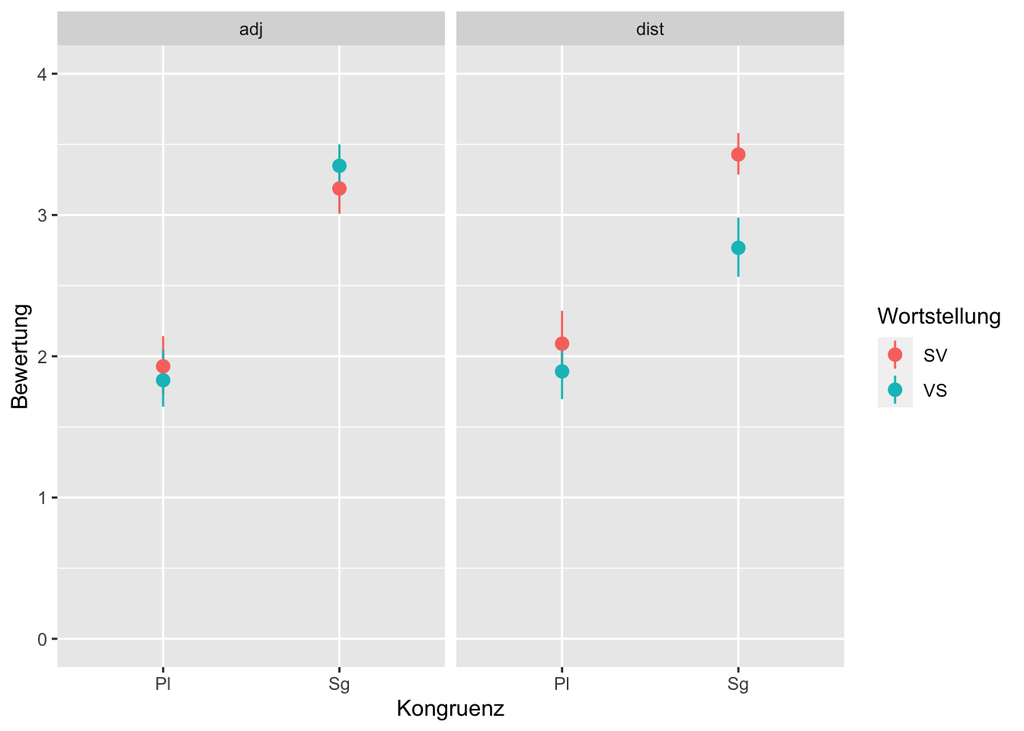

```r
alle_effekte_zweifelsfall1
```

### Teilstudie 2 (Zweifelsfall 2)

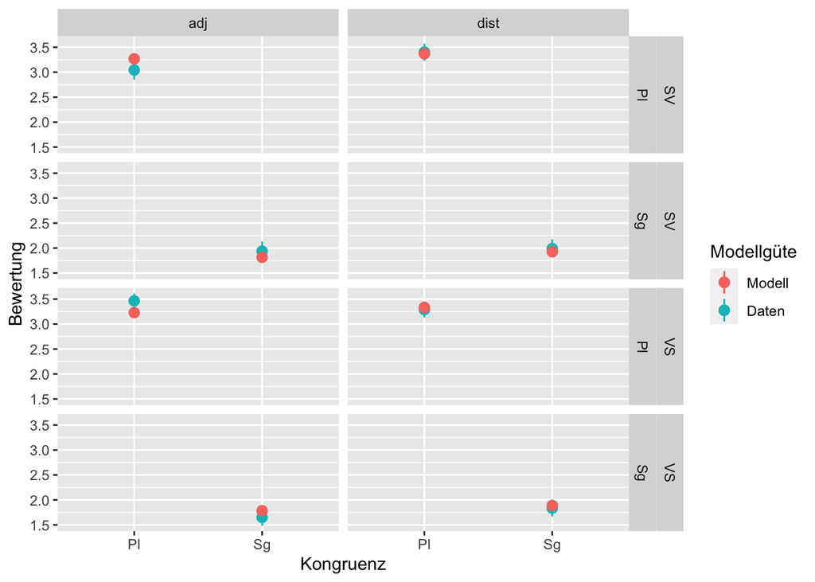

```r
modell_fit_zweifelsfall2 <-
  ggplot(zweifelsfall2, aes(x=Kongruenz, y=Bewertung)) +
  stat_summary(aes(color="observed"), fun.data=mean_cl_boot) +
  stat_summary(aes(y=FittedBewertung, color="model"), fun.data=mean_cl_boot) + facet_grid(Wortstellung ~ Kongruenz ~ Distanz) + xlab("Kongruenz") + ylab("Bewertung") + scale_color_discrete(name  ="Modellgüte", breaks=c("model", "observed"), labels=c("Modell", "Daten"))

alle_effekte_zweifelsfall2 <-
  ggplot(zweifelsfall2, aes(x=Kongruenz, y=Bewertung, color=Wortstellung)) + stat_summary(fun.data=mean_cl_boot) + facet_wrap(~Distanz) + xlab("Kongruenz") + ylab("Bewertung") + ylim(0, 4)

modell_fit_zweifelsfall2
```

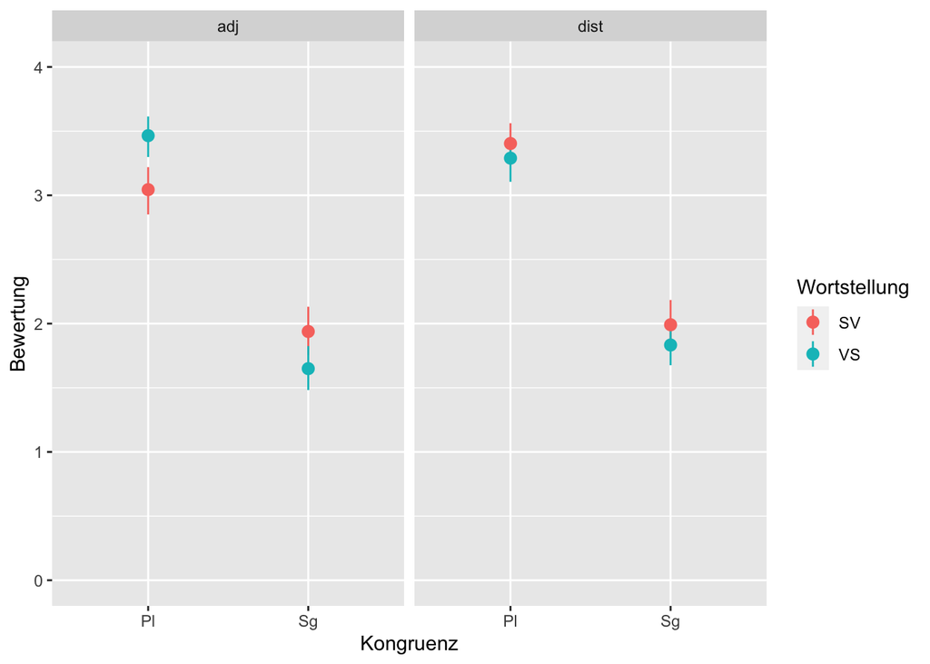

```r
alle_effekte_zweifelsfall2
```

### Teilstudie 3 (Zweifelsfall 3)

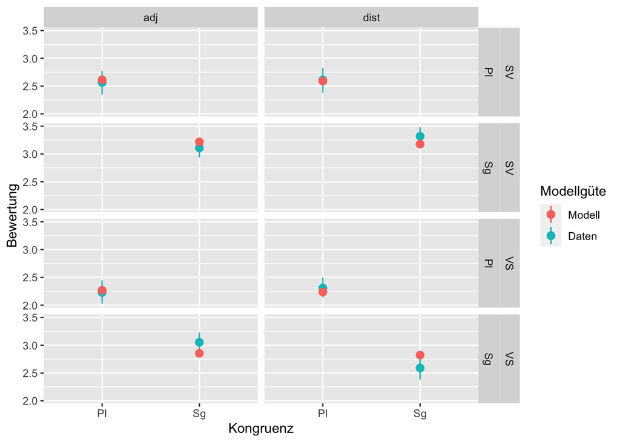

```r
modell_fit_zweifelsfall3 <-
  ggplot(zweifelsfall3, aes(x=Kongruenz, y=Bewertung)) +
  stat_summary(aes(color="observed"), fun.data=mean_cl_boot) +
  stat_summary(aes(y=FittedBewertung, color="model"), fun.data=mean_cl_boot) + facet_grid(Wortstellung ~ Kongruenz ~ Distanz) + xlab("Kongruenz") + ylab("Bewertung") + scale_color_discrete(name  ="Modellgüte", breaks=c("model", "observed"), labels=c("Modell", "Daten"))

alle_effekte_zweifelsfall3 <-
  ggplot(zweifelsfall3, aes(x=Kongruenz, y=Bewertung, color=Wortstellung)) + stat_summary(fun.data=mean_cl_boot) + facet_wrap(~Distanz) + xlab("Kongruenz") + ylab("Bewertung") + ylim(0, 4)

modell_fit_zweifelsfall3
```

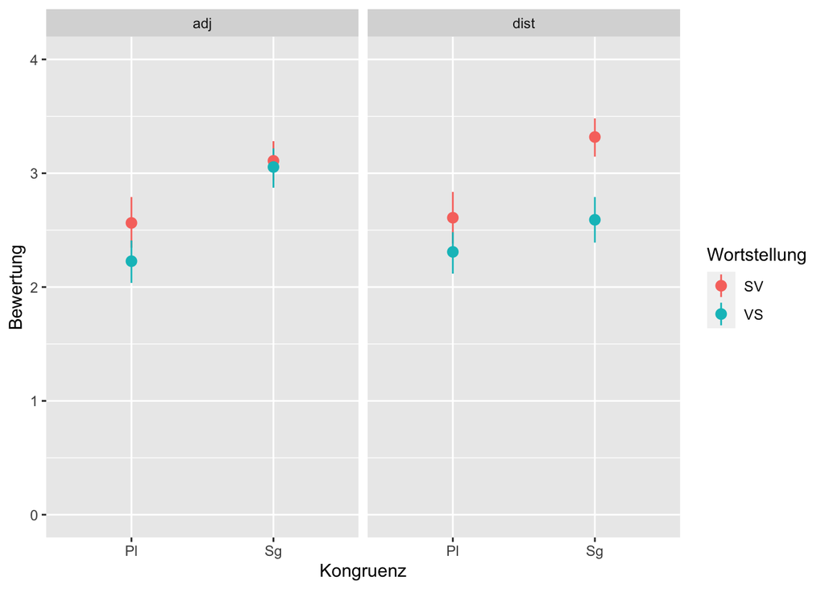

```r
alle_effekte_zweifelsfall3
```

Codeschnipsel für das Plotten einzelner Effekte und zum Speichern der Plots:

```r
einzelne_effekte_zweifelsfall1 <-
  ggplot(subset(zweifelsfall1, Distanz=='adj'), aes(x=Kongruenz, y=Bewertung, color=Wortstellung)) + stat_summary(fun.data=mean_cl_boot) + xlab("Kongruenz") + ylab("Bewertung") + ylim(0, 4)

# Working directory anpassen (müssen Sie entsprechend ändern)

setwd("/Users/uetzelsche/Desktop")

alle_effekte_zweifelsfall1
quartz.save("zweifelfall1.png","png", dpi = 150)

modell_fit_zweifelsfall1
quartz.save("fit_zweifelfall1.png","png", dpi = 150)
```

## Appendix: Mass- vs. Count-Nomen

In Teilstudie 1 wurden auch Mass- und Count-Nomen systematisch variiert, so dass wir diesen Faktor zusätzlich berücksichtigen können. Items `SA` und `SC` im Originaldatensatz sind Massenomen, Items `SB` und `SD` sind Zählnomen. Da `Item` nun als fixer Effekt betrachtet wird, nehmen wir nur `CASE` als zufälligen Effekt

```r
zweifelsfall1_alternativ <- filter(daten_kongruenz_mod, Item %in% c("A", "B", "C", "D"))

zweifelsfall1_alternativ <-
  zweifelsfall1_alternativ %>%
  mutate(Quantifikation = as.factor(ifelse(Item == 'A' | Item == 'C', "mass", ifelse(Item == 'B' | Item == 'D', "count", NA)))) %>%
  drop_na()

modell_alternativ <- lmer(Bewertung ~ Wortstellung + Quantifikation + Kongruenz + Distanz + (1|CASE), zweifelsfall1_alternativ, REML= TRUE)

summary(modell_alternativ)
```

```
## Linear mixed model fit by REML ['lmerMod']
## Formula: Bewertung ~ Wortstellung + Quantifikation + Kongruenz + Distanz +
##     (1 | CASE)
##    Data: zweifelsfall1_alternativ
##
## REML criterion at convergence: 2582.2
##
## Scaled residuals:
##     Min      1Q  Median      3Q     Max
## -2.3993 -0.7564 -0.0325  0.7459  2.5421
##
## Random effects:
##  Groups   Name        Variance Std.Dev.
##  CASE     (Intercept) 0.06603  0.2570
##  Residual             0.97862  0.9893
## Number of obs: 896, groups:  CASE, 56
##
## Fixed effects:
##                    Estimate Std. Error t value
## (Intercept)         2.76786    0.05800  47.725
## Wortstellung[S.SV]  0.09933    0.03305   3.006
## Quantifikationmass -0.41741    0.06610  -6.315
## Kongruenz[S.Pl]    -0.62388    0.03305 -18.878
## Distanz[S.adj]      0.01451    0.03305   0.439
##
## Correlation of Fixed Effects:
##             (Intr) W[S.SV Qntfkt K[S.P]
## Wrtst[S.SV]  0.000
## Quntfktnmss -0.570  0.000
## Kngrnz[S.P]  0.000  0.000  0.000
## Dstnz[S.dj]  0.000  0.000  0.000  0.000
```

```r
Anova(modell_alternativ)
```

```
## Analysis of Deviance Table (Type II Wald chisquare tests)
##
## Response: Bewertung
##                   Chisq Df Pr(>Chisq)
## Wortstellung     9.0335  1   0.002651 **
## Quantifikation  39.8804  1    2.7e-10 ***
## Kongruenz      356.3689  1  < 2.2e-16 ***
## Distanz          0.1927  1   0.660649
## ---
## Signif. codes:  0 '***' 0.001 '**' 0.01 '*' 0.05 '.' 0.1 ' ' 1
```

```r
zweifelsfall1_alternativ$FittedBewertung <- fitted(modell_alternativ)
```

Eine Prüfung der Modellgüte in Bezug auf die zufälligen Faktoren (Rückwärtsselektion modulo AIC) deutet darauf hin, dass das Maximalmodell am besten abschneidet. Wir plotten nun die Daten mit dem zusätzlichen Faktor sowie die Güte des alternativen Modells.

```r
modell_alternativ_step <- stepcAIC(modell_alternativ, direction = "backward", trace = TRUE, data = zweifelsfall1_alternativ)
```

```
## Starting stepwise procedure...
## _____________________________________________
## _____________________________________________
##
## Step 1 (backward):  cAIC=2560.915
## Best model so far:
## ~ Wortstellung + Quantifikation + Kongruenz + Distanz + (1 | CASE)
## New Candidates:
##
## Calculating cAIC for 1 model(s) ...
##
##                                                models caic
##  ~Wortstellung + Quantifikation + Kongruenz + Distanz 2588
##
## _____________________________________________
## _____________________________________________
##
## Best model:
##  ~ Wortstellung + Quantifikation + Kongruenz + Distanz + (1 | CASE) ,
##  cAIC: 2560.915
## _____________________________________________
```

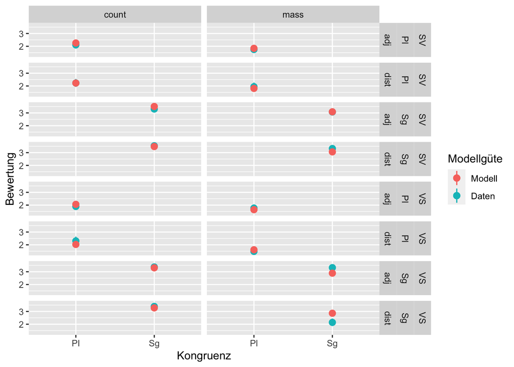

```r
modell_fit_zweifelsfall1_alternativ <-
  ggplot(zweifelsfall1_alternativ, aes(x=Kongruenz, y=Bewertung)) +
  stat_summary(aes(color="observed"), fun.data=mean_cl_boot) +
  stat_summary(aes(y=FittedBewertung, color="model"), fun.data=mean_cl_boot) + facet_grid(Wortstellung ~ Kongruenz ~ Distanz ~ Quantifikation) + xlab("Kongruenz") + ylab("Bewertung") + scale_color_discrete(name  ="Modellgüte", breaks=c("model", "observed"), labels=c("Modell", "Daten"))

alle_effekte_zweifelsfall1_alternativ <-
  ggplot(zweifelsfall1_alternativ, aes(x=Kongruenz, y=Bewertung, color=Wortstellung)) + stat_summary(fun.data=mean_cl_boot) + facet_wrap(~Distanz + Quantifikation) + xlab("Kongruenz") + ylab("Bewertung") + ylim(0, 4)

modell_fit_zweifelsfall1_alternativ
```

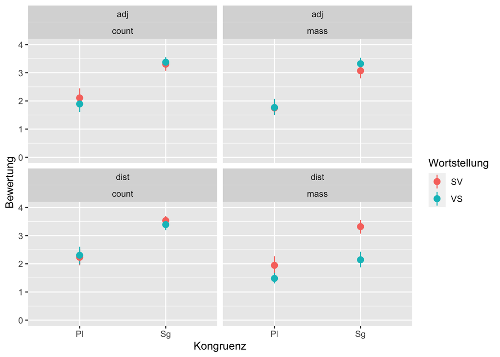

```r
alle_effekte_zweifelsfall1_alternativ
```